# R-Exercises related to ‘dplyr’

Can Aytöre

11/08/2020

## Overview of dataset ‘raw_df’:

```r
print(raw_df,n=3)
```

```
## # A tibble: 21,168 x 17
##   dt                  wind_lic geothermal_lic biogas_lic canalType_lic
##   <dttm>                 <dbl>          <dbl>      <dbl>         <dbl>
## 1 2020-05-31 23:00:00    1434.           913.       75.8         2585.
## 2 2020-05-31 22:00:00    1577.           908.       75.6         2631.
## 3 2020-05-31 21:00:00    1858.           901.       75.4         2585.
## # ... with 21,165 more rows, and 12 more variables: riverType_lic <dbl>,
## #   biomass_lic <dbl>, landfillGas_lic <dbl>, sun_lic <dbl>,
## #   reservoir_lic <dbl>, others_lic <dbl>, wind_ul <dbl>, biogas_ul <dbl>,
## #   canalType_ul <dbl>, biomass_ul <dbl>, sun_ul <dbl>, others_ul <dbl>
```

```r
raw_df %>% glimpse()
```

```
## Rows: 21,168
## Columns: 17
## $ dt              <dttm> 2020-05-31 23:00:00, 2020-05-31 22:00:00, 2020-05-...
## $ wind_lic        <dbl> 1433.8132, 1577.1419, 1857.5492, 1933.0142, 2031.78...
## $ geothermal_lic  <dbl> 912.7882, 907.9303, 900.5844, 888.4561, 864.5402, 8...
## $ biogas_lic      <dbl> 75.8047, 75.6163, 75.3906, 76.7873, 76.9707, 77.575...
## $ canalType_lic   <dbl> 2584.930, 2630.602, 2585.038, 2542.381, 2594.459, 2...
## $ riverType_lic   <dbl> 316.5538, 316.6800, 356.7637, 350.1544, 377.5312, 3...
## $ biomass_lic     <dbl> 262.4994, 253.0814, 246.9268, 249.9152, 248.2336, 2...
## $ landfillGas_lic <dbl> 100.3971, 101.1378, 100.4442, 100.7307, 102.2474, 1...
## $ sun_lic         <dbl> 0.0000, 0.0000, 0.0000, 0.0000, 2.0594, 14.2800, 48...
## $ reservoir_lic   <dbl> 2306.303, 2296.045, 2279.266, 2308.918, 2792.313, 3...
## $ others_lic      <dbl> 48.3833, 48.4011, 48.4041, 48.4199, 48.4653, 48.548...
## $ wind_ul         <dbl> 3.7751, 4.8375, 7.6659, 11.8121, 13.1070, 13.1830, ...
## $ biogas_ul       <dbl> 16.9293, 16.9227, 16.9052, 16.7517, 16.2928, 16.598...
## $ canalType_ul    <dbl> 4.1749, 4.4221, 4.4658, 4.6020, 4.6195, 4.5146, 4.6...
## $ biomass_ul      <dbl> 15.4698, 15.3609, 16.0483, 15.2271, 15.5563, 15.500...
## $ sun_ul          <dbl> 0.0582, 0.0320, 0.0335, 1.3121, 103.3267, 555.5787,...
## $ others_ul       <dbl> 0.0610, 0.0395, 0.4136, 0.5508, 0.7106, 1.3775, 2.7...
```

## In-class Exercises:

### In-class Exercise 1)

Calculate the daily total production and plot the hourly change of production for ‘wind_lic’ and 2020-04-02.

```r
return_daily_production <- function(the_date,the_column){
  raw_df %>%
    filter(as_date(dt) == the_date) %>%
    arrange(dt) %>%
    select(dt, the_column)
}
# The_date and the_column are already defined in the beginning under 'params'.
daily_prod_df <- return_daily_production(params$the_date, params$the_column)
knitr::kable(daily_prod_df)
```

| dt | wind_lic |
| --- | --- |
| 2020-04-02 00:00:00 | 1376.317 |
| 2020-04-02 01:00:00 | 1484.757 |
| 2020-04-02 02:00:00 | 1643.236 |
| 2020-04-02 03:00:00 | 1863.580 |
| 2020-04-02 04:00:00 | 2076.822 |
| 2020-04-02 05:00:00 | 2367.872 |
| 2020-04-02 06:00:00 | 2481.355 |
| 2020-04-02 07:00:00 | 2323.889 |
| 2020-04-02 08:00:00 | 2017.700 |
| 2020-04-02 09:00:00 | 1966.403 |
| 2020-04-02 10:00:00 | 1989.430 |
| 2020-04-02 11:00:00 | 2168.680 |
| 2020-04-02 12:00:00 | 2433.737 |
| 2020-04-02 13:00:00 | 2701.929 |
| 2020-04-02 14:00:00 | 2844.760 |
| 2020-04-02 15:00:00 | 3019.050 |
| 2020-04-02 16:00:00 | 3040.508 |
| 2020-04-02 17:00:00 | 3189.575 |
| 2020-04-02 18:00:00 | 3281.175 |
| 2020-04-02 19:00:00 | 3483.915 |
| 2020-04-02 20:00:00 | 3420.224 |
| 2020-04-02 21:00:00 | 3102.883 |
| 2020-04-02 22:00:00 | 2917.997 |
| 2020-04-02 23:00:00 | 2803.036 |

- Total production is **59999**.

Plotting the hourly change of production:

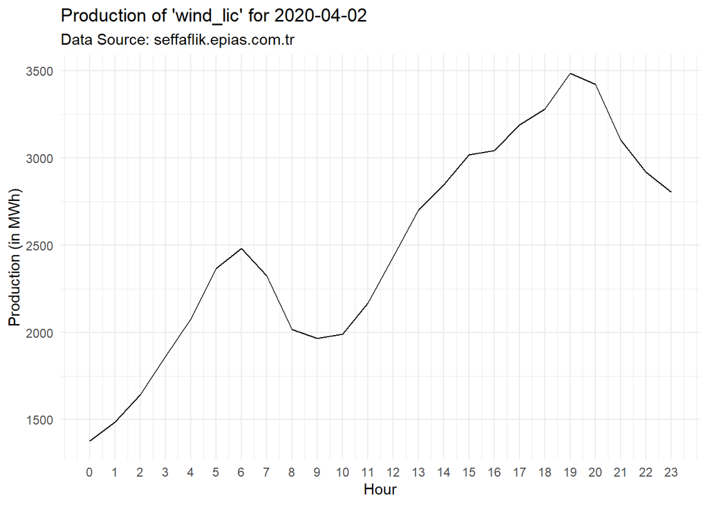

```r
# Start with the canvas ggplot function
ggplot(daily_prod_df) +
  # Define aesthetics and plot type
  geom_line(aes(x=lubridate::hour(dt), y=!!as.symbol(params$the_column))) +
  # Get predefined theme: theme minimal
  theme_minimal() +
  # Change labels and make title parametric
  labs(x="Hour", y="Production (in MWh)",
       title = paste0("Production of '", params$the_column, "' for ", params$the_date),
       subtitle = "Data Source: seffaflik.epias.com.tr") +
  # Change x axis breaks so each hour is displayed individually
  scale_x_continuous(breaks = 0:23)
```

### In-class Exercise 2) Monthly Hydro Production Analysis

Below you can see which months have the highest hydro production and changes in terms of percentage.

```r
raw_df %>%
  # select date-time and hydro related columns
  select(dt, canalType_lic, riverType_lic, reservoir_lic) %>%
  # calculate total hydro production
  mutate(total_hydro = canalType_lic + riverType_lic + reservoir_lic) %>%
  # group by year-month using lubridate
  group_by(year = lubridate::year(dt), month = lubridate::month(dt)) %>%
  # get monthly totals
  summarise(total_canal = sum(canalType_lic), total_river = sum(riverType_lic), total_reservoir = sum(reservoir_lic), total = sum(total_hydro)) %>%
  # ungroup
  ungroup() %>%
  # sort by total hydro production descending to get the highest production months
  arrange(desc(total)) %>%
  # rearrange columns for convenience
  relocate(total,.after=month) %>%
  # offset production by one row above so we can calculate production changes
  mutate(lead_total = lead(total,1),.after=total) %>%
  # calculate percentage increases between ranks
  mutate(perc_change = total/lead_total - 1) %>%
  # return just relevant columns from year to lead_total and percentage change
  select(year:lead_total, perc_change)
```

```
## # A tibble: 29 x 5
##     year month    total lead_total perc_change
##    <dbl> <dbl>    <dbl>      <dbl>       <dbl>
##  1  2019     5 6489784.   5675201.     0.144
##  2  2019     4 5675201.   5087625.     0.115
##  3  2020     5 5087625.   4809446.     0.0578
##  4  2020     4 4809446.   4662190.     0.0316
##  5  2020     3 4662190.   4009868.     0.163
##  6  2019     6 4009868.   4000380.     0.00237
##  7  2019     3 4000380.   3780435.     0.0582
##  8  2018     3 3780435.   3668319.     0.0306
##  9  2019     1 3668319.   3638288.     0.00825
## 10  2018     5 3638288.   3316165.     0.0971
## 11  2018     4 3316165.   3223725.     0.0287
## 12  2019     2 3223725.   3129490.     0.0301
```

[output cut: 17 more lines]

## Other Exercises:

### Exercise 1)

Find the mean and standard deviation of licensed geothermal ‘geothermal_lic’ productions in all years. (Tip: Use lubridate::year to get years from date data.)

```r
raw_df %>%
  # select date-time and licensed geothermal production
  select(dt, geothermal_lic) %>%
  # group by year using lubridate
  group_by(year = lubridate::year(dt)) %>%
  # get mean and standard deviation
  summarise(mean_geo = mean(geothermal_lic), sd_geo = sd(geothermal_lic)) %>%
  # ungroup
  ungroup() %>%
  # sort by year
  arrange(year) %>%
  # return just relevant columns
  select(year, mean_geo, sd_geo)
```

```
## # A tibble: 3 x 3
##    year mean_geo sd_geo
##   <dbl>    <dbl>  <dbl>
## 1  2018     681.   65.2
## 2  2019     799.   74.2
## 3  2020     935.   59.0
```

### Exercise 2)

Find the hourly average unlicensed solar ‘sun_ul’ production levels for May 2020.

```r
raw_df %>%
  # filter the year and month
  filter(lubridate::year(dt) == 2020 & lubridate::month(dt) == 05) %>%
  # select date-time and unlicensed solar production
  select(dt, sun_ul) %>%
  # group by year using lubridate
  group_by(hour = lubridate::hour(dt)) %>%
  # get the average of production
  summarise(avg_prod = round(mean(sun_ul),2)) %>%
  # ungroup
  ungroup() %>%
  # sort by hour
  arrange(hour) %>%
  # return just relevant columns
  select(hour, avg_prod)
```

```
## # A tibble: 24 x 2
##     hour avg_prod
##    <int>    <dbl>
##  1     0     0.17
##  2     1     0.37
##  3     2     0.7
##  4     3     0.91
##  5     4     1.26
##  6     5    22.7
##  7     6   305.
##  8     7  1156.
##  9     8  2316.
## 10     9  3330.
## 11    10  3995.
## 12    11  4298.
## 13    12  4332.
## 14    13  4230.
## 15    14  3947.
## 16    15  3357.
## 17    16  2510.
## 18    17  1476.
## 19    18   540.
## 20    19    80.3
## 21    20     0.48
## 22    21     0.06
## 23    22     0.03
## 24    23     0.06
```

### Exercise 3)

```r
raw_df %>%
  # filter the year
  filter(lubridate::year(dt) == 2019) %>%
  # select date-time and biomass_lic production
  select(dt, biomass_lic) %>%
  # group by day using lubridate
  group_by(date = lubridate::as_date(dt)) %>%
  # get daily total
  summarise(daily_total = sum(biomass_lic)) %>%
  # ungroup
  ungroup() %>%
  # sort by date
  arrange(date) %>%
  # offset production by one row above so we can calculate production changes
  mutate(lag_daily_total = lag(daily_total,1)) %>%
  # calculate percentage changes
  mutate(perc_change = (daily_total - lag_daily_total)/lag_daily_total - 1) %>%
  # get the average change
  summarise(average_change = mean(perc_change, na.rm = TRUE)) %>%
  # return just relevant column
  select(average_change)
```

```
## # A tibble: 1 x 1
##   average_change
##            <dbl>
## 1         -0.998
```

### Exercise 4)

Find the yearly total production levels in TWh (Current values are in MWh. 1 GWh is 1000 MWh and 1 TWh is 1000 GWh). (Tip: In order to avoid a lengthy summation you can use tidyr::pivot_longer to get a long format.)

```r
raw_df %>%
  # select all columns
  select(dt:others_ul) %>%
  # group by year using lubridate
  group_by(year = lubridate::year(dt)) %>%
  # get total_production by summing up
  summarise(total_production = sum(wind_lic+geothermal_lic+biogas_lic+canalType_lic+riverType_lic+biomass_lic+landfillGas_lic+sun_lic+reservoir_lic+others_lic+wind_ul+biogas_ul+canalType_ul+biomass_ul+sun_ul+others_ul)/(10^6)) %>%
  # ungroup
  ungroup() %>%
  # sort by year
  arrange(year) %>%
  # return just relevant columns
  select(year, total_production)
```

```
## # A tibble: 3 x 2
##    year total_production
##   <dbl>            <dbl>
## 1  2018             62.6
## 2  2019             76.7
## 3  2020             37.3
```